# Self-Driving Car Engineer Nanodegree

## Project: Build a Traffic Sign Recognition Classifier

In this notebook, a template is provided for you to implement your functionality in stages which is required to successfully complete this project. If additional code is required that cannot be included in the notebook, be sure that the Python code is successfully imported and included in your submission, if necessary. Sections that begin with **'Implementation'** in the header indicate where you should begin your implementation for your project. Note that some sections of implementation are optional, and will be marked with **'Optional'** in the header.

In addition to implementing code, there will be questions that you must answer which relate to the project and your implementation. Each section where you will answer a question is preceded by a **'Question'** header. Carefully read each question and provide thorough answers in the following text boxes that begin with **'Answer:'**. Your project submission will be evaluated based on your answers to each of the questions and the implementation you provide.

> **Note:** Code and Markdown cells can be executed using the **Shift + Enter** keyboard shortcut. In addition, Markdown cells can be edited by typically double-clicking the cell to enter edit mode.

## Step 0: Load The Data

```python
# Load pickled data
import pickle
import numpy as np

# TODO: Fill this in based on where you saved the training and testing data

training_file = "data/train.p"
testing_file = "data/test.p"

with open(training_file, mode='rb') as f:
    train = pickle.load(f)
with open(testing_file, mode='rb') as f:
    test = pickle.load(f)

X_train, y_train = train['features'], train['labels']
X_test, y_test = test['features'], test['labels']
```

## Step 1: Dataset Summary & Exploration

The pickled data is a dictionary with 4 key/value pairs:

- `'features'` is a 4D array containing raw pixel data of the traffic sign images, (num examples, width, height, channels).
- `'labels'` is a 2D array containing the label/class id of the traffic sign. The file `signnames.csv` contains id -> name mappings for each id.
- `'sizes'` is a list containing tuples, (width, height) representing the the original width and height the image.
- `'coords'` is a list containing tuples, (x1, y1, x2, y2) representing coordinates of a bounding box around the sign in the image. **THESE COORDINATES ASSUME THE ORIGINAL IMAGE. THE PICKLED DATA CONTAINS RESIZED VERSIONS (32 by 32) OF THESE IMAGES**

Complete the basic data summary below.

```python
### Replace each question mark with the appropriate value.

# TODO: Number of training examples
n_train = len(X_train)

# TODO: Number of testing examples.
n_test = len(X_test)

# TODO: What's the shape of an traffic sign image?
image_shape = X_train[0].shape

# TODO: How many unique classes/labels there are in the dataset.
n_classes = len(np.unique(y_train))

print("Number of training examples =", n_train)
print("Number of testing examples =", n_test)
print("Image data shape =", image_shape)
print("Number of classes =", n_classes)
```

```
Number of training examples = 39209
Number of testing examples = 12630
Image data shape = (32, 32, 3)
Number of classes = 43
```

Visualize the German Traffic Signs Dataset using the pickled file(s). This is open ended, suggestions include: plotting traffic sign images, plotting the count of each sign, etc.

The [Matplotlib](http://matplotlib.org/) [examples](http://matplotlib.org/examples/index.html) and [gallery](http://matplotlib.org/gallery.html) pages are a great resource for doing visualizations in Python.

**NOTE:** It's recommended you start with something simple first. If you wish to do more, come back to it after you've completed the rest of the sections.

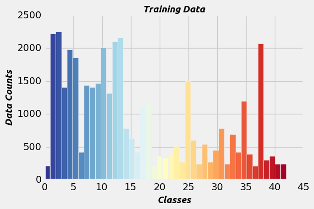

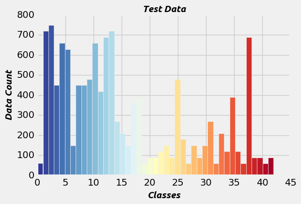

```python
### Data exploration visualization goes here.
### Feel free to use as many code cells as needed.

import matplotlib.pyplot as plt
# Visualizations will be shown in the notebook.
%matplotlib inline
# For more plots:www.futurile.net/2016/02/27/matplotlib-beautiful-plots-with-style/
plt.style.use('fivethirtyeight')

# Function for color-coding of a given colormap.
def Color_fun():
    cm = plt.cm.get_cmap('RdYlBu_r')
    bin_centers = 0.5 * (bins[:-1] + bins[1:])
    # scale values to interval [0,1]
    col = bin_centers - min(bin_centers)
    col /= max(col)
    for c, p in zip(col, patches):
        plt.setp(p, 'facecolor', cm(c))

# Histogram to visualize the Training data
n, bins, patches = plt.hist(y_train, bins = n_classes)
Color_fun()
plt.xlabel('Classes', fontname='Ubuntu', fontsize=14,fontstyle='italic', fontweight='bold')
plt.ylabel('Data Counts', fontname='Ubuntu', fontsize=14,fontstyle='italic', fontweight='bold')
plt.title("Training Data", fontname='Ubuntu', fontsize=14,fontstyle='italic', fontweight='bold')
plt.show();

# Histogram to visualize of Test data
n, bins, patches = plt.hist(y_test, bins = n_classes)
Color_fun()
plt.xlabel('Classes', fontname='Ubuntu', fontsize=14,fontstyle='italic', fontweight='bold')
plt.ylabel('Data Count', fontname='Ubuntu', fontsize=14,fontstyle='italic', fontweight='bold')
plt.title('Test Data', fontname='Ubuntu', fontsize=14,fontstyle='italic', fontweight='bold')
plt.show();
```

Intuition: From the Training set and Test set histograms it is clearly evident that both are very unbalanced for different traffic signs. Few of the traffic signs have more than 2000 images and few have less than 500. Additional data would be useful for the less sampled traffic signs.

```python
#Intuition explained
dist_train = np.histogram(y_train, bins=range(44))
dist_test = np.histogram(y_test, bins=range(44))
classes_train = dist_train[1]
count_train = dist_train[0]
classes_test = dist_test[1]
count_test = dist_test[0]

print("Max and Min images for a class in Training Set:", max(count_train),min(count_train))
print("Max and Min images for a class in Test Set:", max(count_test),min(count_test))
```

```
Max and Min images for a class in Training Set: 2250 210
Max and Min images for a class in Test Set: 750 60
```

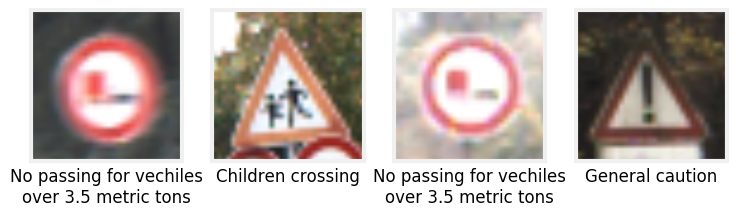

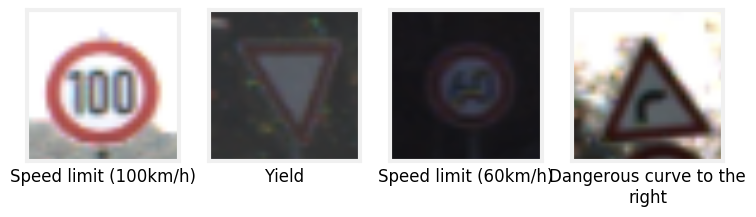

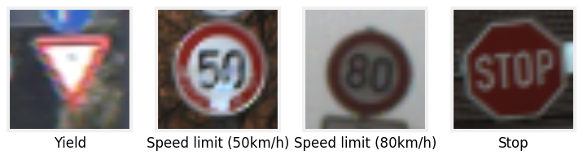

```python
### Data exploration visualization goes here.
### Feel free to use as many code cells as needed.
# Function to plot images from random classes
# Make dictionary of sign names from CSV file
import csv
%matplotlib inline
import matplotlib

with open('signnames.csv', 'r') as csvfile:
    reader = csv.reader(csvfile)
    next(reader, None)  # skip the headers
    sign_names = dict((int(n),label) for n, label in reader)

cls_numbers, cls_names = zip(*sign_names.items())


matplotlib.rcParams['figure.figsize'] = (8, 6)

import matplotlib.pyplot as plt
import random
import textwrap

def plot_images(images, cls_true, cls_pred=None, count=12, num_per_row=4, randomize=True):
    ctr = 0
    global sign_names

    if randomize:
        iterator = random.sample(range(len(images)), count)
    else:
        iterator = range(min(count, len(images)))

    for i in iterator:
        X, y_true = images[i,:], cls_true[i]

        if ctr % num_per_row == 0:
            # Create new row
            plt.figure()

        plt.subplot(1, num_per_row, (ctr % num_per_row) + 1)
        ax = plt.gca()
        plt.imshow(X)

        # Show the classes as the label on the x-axis.
        true_label = textwrap.fill(sign_names[y_true], 25)
        if cls_pred is not None:
            y_pred = cls_pred[i]

            pred_label = textwrap.fill(sign_names[y_pred], 25)
            ax.set_xlabel('True : {0} \n Pred: {1}'.format(true_label, pred_label))
        else:
            ax.set_xlabel(true_label)

        # Remove ticks from the plot.
        ax.set_xticks([])
        ax.set_yticks([])

        ctr += 1

plot_images(X_train, y_train)
plt.show()
```

[figure not shown]

```python
# Function to plot an image for each class
def display_images_and_labels(images, labels):
    unique_labels = set(labels)
    plt.figure(figsize=(15, 15))
    i = 1
    for label in unique_labels:
        # Count of the current label
        cnt = sum(labels == label)
        # Pick arandom image for each label.
        img_ind = random.choice(np.where(labels == label)[0])
        image = images[img_ind]
        plt.subplot(8, 8, i)
        plt.axis('off')
        plt.title('Label %d (%d)' % (label, cnt))
        i += 1
        plt.imshow(image)
    plt.show()

display_images_and_labels(X_train, y_train)
```

## Step 2: Design and Test a Model Architecture

Design and implement a deep learning model that learns to recognize traffic signs. Train and test your model on the [German Traffic Sign Dataset](http://benchmark.ini.rub.de/?section=gtsrb&subsection=dataset).

There are various aspects to consider when thinking about this problem:

- Neural network architecture
- Play around preprocessing techniques (normalization, rgb to grayscale, etc)
- Number of examples per label (some have more than others).
- Generate fake data.

Here is an example of a [published baseline model on this problem](http://yann.lecun.com/exdb/publis/pdf/sermanet-ijcnn-11.pdf). It's not required to be familiar with the approach used in the paper but, it's good practice to try to read papers like these.

**NOTE:** The LeNet-5 implementation shown in the classroom at the end of the CNN lesson is a solid starting point. You'll have to change the number of classes and possibly the preprocessing, but aside from that it's plug and play!

### Implementation

Use the code cell (or multiple code cells, if necessary) to implement the first step of your project. Once you have completed your implementation and are satisfied with the results, be sure to thoroughly answer the questions that follow.

# GPU Version

This version badly needs a good CPU or a GPU. Tried it on the Amazon Web Services. My lappy could died running this:P I have an old lappy :( so I am probably thinking this might work on laptops.

Implemented Min-Max scaling in the `normalize_img()` function to a range of `a=-1.0` and `b=1.0`. After scaling, the values of the pixels in the input data should range from -1 to 1. Min-Max Scaling: $ X'=a+{\frac {\left(X-X_{\min }\right)\left(b-a\right)}{X_{\max }-X_{\min }}} $

```python
### Preprocess the data here.
### Feel free to use as many code cells as needed.
from sklearn.preprocessing import LabelBinarizer
#http://scikit-learn.org/stable/modules/generated/sklearn.preprocessing.LabelBinarizer.html

# Knowledge gained from TensorFlow Lab
# Implemented Min-Max scaling for the image data
# Transform features by scaling each feature to a given range.
def normalize_img(img):
    x_min = 0
    x_max = 255
    a = -1.0
    b = 1.0
    return a + (img - x_min) * (b - a) / (x_max - x_min)

X_train = normalize_img(X_train)
X_test = normalize_img(X_test)

# Implemented one-hot encoding
encoder = LabelBinarizer()
encoder.fit(y_train)
y_train = encoder.transform(y_train)
y_test = encoder.transform(y_test)

# Change to float32, so it can be multiplied against the features in TensorFlow, which are float32
y_train = y_train.astype(np.float32)
y_test = y_test.astype(np.float32)
```

### Question 1

*Describe how you preprocessed the data. Why did you choose that technique?*

**Answer:**

- Features: Used normailization to keep the image pixel values between -1.0 and 1.0
  - Why Normalization? Normalized data helps Gradient Descent (or similar algorithms) to converge quickly. Hence, data normalization is one of the key preprocessing steps when it comes to data preprocessing. I experimented with preprocessing techniques (namely, MinMax Scaling and Mean Normalization). But during the initial stage of the project, I found out that, MinMax Scaling works better than Mean Normalization for this dataset. Also Normalisation as opoosed to Standardisation gives the higher validation and training accuracy for a feedforward network.
- Labels: One-hot encoding.[One-Hot Encoding was used to convert label numbers to vectors].
- Reason for not converting the image to grayscale:
  - Since color images will be useful for the classifier [Red warns the driver].Ex: Astop sign might be an upside-down red triangle, and knowing the colour of the triangle may help us predict the sign correctly.
- Due to the con's of data reduction:
  - Processing only a single combined channel instead of three separate RGB channels reduces the amount of data to be processed by about 1/3 and allows the algorithm to run faster. However, it comes at the cost of throwing away data (color data) that may be very helpful or required for many image processing applications.

```python
### Generate data additional data (OPTIONAL!)
### and split the data into training/validation/testing sets here.
### Feel free to use as many code cells as needed.

# Used sklearn to split training data into training and validation set.
from sklearn.model_selection import train_test_split

X_train, X_valid, y_train, y_valid = train_test_split(X_train, y_train, test_size = 0.2)

X_train = X_train.astype(np.float32)
X_valid = X_valid.astype(np.float32)
X_test = X_test.astype(np.float32)

print("Trainning Set Data Size: %d" % X_train.shape[0])
print("Validation Set Data Size:%d" % X_valid.shape[0])
print("Test Set Data Size: %d" % X_test.shape[0])
```

```
Trainning Set Data Size: 31367
Validation Set Data Size:7842
Test Set Data Size: 12630
```

### Question 2

*Describe how you set up the training, validation and testing data for your model. **Optional**: If you generated additional data, how did you generate the data? Why did you generate the data? What are the differences in the new dataset (with generated data) from the original dataset?*

**Answer:**

- The training data is shuffled because they were arranged in the ascending order by label. If we don't shuffle the training data, the batches will learn the first type of sign followed by the second type and so on. It will certainly fool us and falsify the learning process.
- 20% of the training data is used for validation, and the final accuracy score was determined by running the model on the provided test dataset.
- Validation data will be used to evaluate the performance of the neural network at each training epoch.

Tensorflow Recap

- tf.placeholder() returns a tensor that gets its value from data passed to the tf.session.run() function, allowing us to set the input right before the session runs.
- tf.truncated_normal() function returns a tensor with random values from a normal distribution whose magnitude is no more than 2 standard deviations from the mean.

```python
### Define your architecture here.
### Feel free to use as many code cells as needed.

import tensorflow as tf

# Input image size
image_size = X_train[0].shape[0]
num_channels = X_train[0].shape[2]

# Filter size
kernel_size = 5
depth1 = 32
depth2 = 64
num_hidden = 1024

graph = tf.Graph()
with graph.as_default():
    features = tf.placeholder(tf.float32, [None, image_size, image_size, num_channels])
    labels = tf.placeholder(tf.float32, [None, n_classes])
    keep_prob = tf.placeholder(tf.float32)
    beta = tf.placeholder(tf.float32)
    learning_rate = tf.placeholder(tf.float32)

    # Imp: Depth doesn't change during pooling operation
    # The goal of training a neural network is to modify weights and biases to best predict the labels.

    weights =  {
        'layer1': tf.Variable(tf.truncated_normal(shape = [kernel_size, kernel_size, num_channels, depth1],
                                                  stddev = 0.1)),
        'layer2': tf.Variable(tf.truncated_normal(shape = [kernel_size, kernel_size, depth1, depth2],
                                                  stddev = 0.1)),
        # '4' here because we have 2 max pooling with stride of 2
        'layer3': tf.Variable(tf.truncated_normal(shape = [image_size // 4 * image_size // 4 * depth2, num_hidden],
                                                  stddev = 0.1)),
        'layer4': tf.Variable(tf.truncated_normal(shape = [num_hidden, n_classes], stddev = 0.1))
    }

    ''' Introduction to TensorFlow Quiz 13
    Weights are already helping prevent the model from getting stuck,
    we don't need to randomize the bias. Let's use the simplest solution, setting the bias to 0.'''

    biases = {
        'layer1': tf.Variable(tf.zeros([depth1])),
        'layer2': tf.Variable(tf.zeros([depth2])),
        'layer3': tf.Variable(tf.zeros([num_hidden])),
        'layer4': tf.Variable(tf.zeros([n_classes]))
    }

    ''' CNN Lesson 19
    -ksize and strides : [batch, height , width, channels]

    -tf.nn.max_pool() function performs max pooling with the ksize parameter as the size of the filter and
    the strides parameter as the length of the stride. 2x2 filters with a stride of 2x2 are used commonly.

    -If we use 'SAME' padding with a stride of 1 the output width and height are the same as input.
    zero padding is performed to match the size

    -DNN Quiz 6 [Learned the implemenation too]
    Rectified linear unit (ReLU) is type of activation function that is defined as f(x) = max(0, x).
    The function returns 0 if x is negative, otherwise it returns x.

    - CNN Lesson 17
    tf.nn.conv2d() function to compute the convolution with weight as the filter and [1, 1, 1, 1] for the strides.
    TensorFlow uses a stride for each input dimension, [batch, input_height, input_width, input_channels].
    Generally we set the stride for batch and input_channels(first and fourth element in the strides array) to be 1.
    input in my case is features.'''

    # Hidden Layer with ReLU activation function [2nd line]
    # convolution -> activation -> pooling [Repeat the rounds :D]

    # Layer 1, output size: 16 x 16 x 32 [H*W*D]
    conv = tf.nn.conv2d(features, weights['layer1'], strides = [1, 1, 1, 1], padding = 'SAME')
    hidden = tf.nn.relu(conv + biases['layer1'])
    pool = tf.nn.max_pool(hidden, ksize = [1, 2, 2, 1], strides = [1, 2, 2, 1], padding = 'SAME')

    # Layer 2, output size: 8 x 8 x 64
    conv = tf.nn.conv2d(pool, weights['layer2'], [1, 1, 1, 1], padding = 'SAME')
    hidden = tf.nn.relu(conv + biases['layer2'])
    pool = tf.nn.max_pool(hidden, ksize = [1, 2, 2, 1], strides = [1, 2, 2, 1], padding = 'SAME')

    # Layer 3, output size: 1 x 1024
    shape = pool.get_shape().as_list()
    reshape = tf.reshape(pool, shape = [-1, shape[1] * shape[2] * shape[3]])
    hidden = tf.nn.relu(tf.matmul(reshape, weights['layer3']) + biases['layer3'])
    hidden = tf.nn.dropout(hidden, keep_prob)

    # Layer 4, output size: 1 x 43 [Output layer with linear activation: xw + b]
    # Intro to TensorFlow Quiz 13, DNN Lesson 11
    logits = tf.matmul(hidden, weights['layer4']) + biases['layer4']

    '''Now let's prevent the network from over optimising on the training set
       Regularization: Applying artificial constraints on the network that implicitly reduces
       the number of free parameters while not making it more difficult to optimize.
       L2 Regularization from Lesson 15 CNN
       L2 norm of our weights * beta (small constant)'''

    regul = beta * (tf.nn.l2_loss(weights['layer1']) +
                     tf.nn.l2_loss(weights['layer2']) +
                     tf.nn.l2_loss(weights['layer3']) +
                     tf.nn.l2_loss(weights['layer4']) )

    # Defined loss and  Optimizer DNN Lesson 11
    loss = tf.reduce_mean(tf.nn.softmax_cross_entropy_with_logits(logits, labels) + regul)
    optimizer = tf.train.AdamOptimizer(learning_rate).minimize(loss)

    # Probability
    # Introduction to TensorFlow Lesson 12
    # Converting the scores (logits) to probabilities using softmax function
    prediction = tf.nn.softmax(logits)

    # Evaluation op phase :D
    #tf.nn.top_k : https://www.tensorflow.org/api_docs/python/nn/evaluation
    #It returns two tensors: 1)top K value 2) indices of these values in the original tensor.
    top_five = tf.nn.top_k(prediction, 5)

    # Check if predictions are correct
    correct_prediction = tf.equal(tf.argmax(prediction, 1), tf.argmax(labels, 1))
    # Calculate Accuracy
    accuracy = tf.reduce_mean(tf.cast(correct_prediction, tf.float32))
    # Save Model
    saver = tf.train.Saver()
```

```python
### Train your model here.
### Feel free to use as many code cells as needed.

# Maximum epoch number
epochs = 25

# Batch size
batch_size = 128

# Training data size
train_data_size = X_train.shape[0]

# Feed_dict for validation data
feed_dict_valid = {features: X_valid, labels: y_valid, keep_prob: 1.0}

# Feed_dict for test data
feed_dict_test = {features: X_test, labels: y_test, keep_prob: 1.0}

with tf.Session(graph = graph) as session:
    tf.global_variables_initializer().run()
    #tf.initialize_all_variables().run()
    for epoch in range(1, epochs + 1):
        # Shuffle the indices for the trainning data
        ind = np.arange(0, train_data_size)
        np.random.shuffle(ind)
        X_train_shuffle = X_train[ind]
        y_train_shuffle = y_train[ind]
        # Go through all the batches
        # 'train_data_size - batch_size' to ignore the residual samples at end of each epoch
        for batch_ind in range(0, train_data_size - batch_size, batch_size):
            batch_data = X_train_shuffle[batch_ind : (batch_ind + batch_size), :, :, :]
            batch_labels = y_train_shuffle[batch_ind : (batch_ind + batch_size), :]
            feed_dict_train = { features: batch_data,
                                labels: batch_labels,
                                keep_prob: 0.5,
                                beta: 1e-6,
                                learning_rate: 0.001 }
            _, l, acc = session.run([optimizer, loss, accuracy], feed_dict = feed_dict_train)
        print("Epoch: %d\tloss: %f\tAccuracy: %f" %(epoch, l, acc))
        valid_acc = accuracy.eval(feed_dict = feed_dict_valid)
        print("Validation accuracy:\t%f" %valid_acc)
        # If both accuracy better than 0.99, stop running
        if(valid_acc > 0.99 and acc > 0.99):
            break
    print("Test accuracy:\t%f" %accuracy.eval(feed_dict = feed_dict_test))
    # save_model = saver.save(session, "Final-check1")
    saver.save(session, "Final-check1")
    # print("Model saved as %s" %save_model)
```

```
Epoch: 1	loss: 0.568515	Accuracy: 0.843750
Validation accuracy:	0.919281
Epoch: 2	loss: 0.226114	Accuracy: 0.937500
Validation accuracy:	0.973859
Epoch: 3	loss: 0.110450	Accuracy: 0.976562
Validation accuracy:	0.985846
Epoch: 4	loss: 0.104338	Accuracy: 0.984375
Validation accuracy:	0.987759
Epoch: 5	loss: 0.095379	Accuracy: 0.976562
Validation accuracy:	0.990436
Epoch: 6	loss: 0.065401	Accuracy: 0.976562
Validation accuracy:	0.990819
Epoch: 7	loss: 0.027239	Accuracy: 1.000000
Validation accuracy:	0.991202
Test accuracy:	0.928267
```

### Question 3

*What does your final architecture look like? (Type of model, layers, sizes, connectivity, etc.) For reference on how to build a deep neural network using TensorFlow, see Deep Neural Network in TensorFlow from the classroom.*

**Answer:**

### Question 4

*How did you train your model? (Type of optimizer, batch size, epochs, hyperparameters, etc.)*

**Answer:** **Answer:**

1. Optimizer: Adam Optimizer with a learning rate of 0.001. After several trial, Adam Optimizer works better than gradient descent optimizer since it adapts the learning rate better according to the losses.
2. Batch size: 128. If batch size is too big, it takes too much memory. If batch size is too small, the training accuracy is less meaningful with a much smaller sample size.
3. Epochs: 25 with early termination to avoid over fitting. But when both the training accuracy and the validation accuracy is better than 99%,terminate the training process.
4. Regularization beta value: 1e-6. Experimental value.

### Question 5

*What approach did you take in coming up with a solution to this problem? It may have been a process of trial and error, in which case, outline the steps you took to get to the final solution and why you chose those steps. Perhaps your solution involved an already well known implementation or architecture. In this case, discuss why you think this is suitable for the current problem.*

**Answer:**

1. At first,I tried to solve this problem using what I already learned from the lessons (fully connected neural network with dropouts, regularization, learning rate decay) and tuned the hyperparameters. This already depicts in the comments which have been made in my architecture. I also believe that the structure of a convolutional neural network followed by fully connected layers is a standard approach for image recogniztion.In this way, we can capture all the information from convolution so that the position of the sign in the image matter less.The best accuracy which I obtained was around 75%.
2. Then tried a simple convolutional neural network with two conv layers and started tuning the hyperparameters. The best accuracy I could get was 86%.
3. I then started looking up further on how to optimize the conv net by reading some articles like [Choosing Learning Rate](http://datascience.stackexchange.com/questions/410/choosing-a-learning-rate?newreg=652aef31a20b4b0a93c7630f09c65094).It did involve a lot of trail and error.Basically tried a lot of them and settled with the ones give me the best performance.
4. I wasn't able to implement all these techniques as the model takes a really long time to run on my machine. Finally, when I was ready to test my final architecture my model was too slow on a CPU where I obtained only one epoch and the system used to freeze.It had to be ran on a GPU.Used the Amazon Web Services and ran the code on NVIDIA GeForce 6600 GT.

## Step 3: Test a Model on New Images

Take several pictures of traffic signs that you find on the web or around you (at least five), and run them through your classifier on your computer to produce example results. The classifier might not recognize some local signs but it could prove interesting nonetheless.

You may find `signnames.csv` useful as it contains mappings from the class id (integer) to the actual sign name.

### Implementation

Use the code cell (or multiple code cells, if necessary) to implement the first step of your project. Once you have completed your implementation and are satisfied with the results, be sure to thoroughly answer the questions that follow.

```python
### Load the images and plot them here.
### Feel free to use as many code cells as needed.
# Getting the truth label reference from the provided csv file
truth_label = np.genfromtxt('signnames.csv', delimiter=',' ,
                            usecols=(1,), unpack=True,
                            dtype=str,  skip_header=1)
```

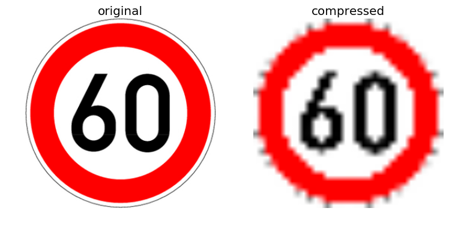

[figure not shown]

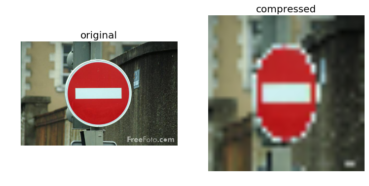

[figure not shown]

[figure not shown]

```python
### Load the images and plot them here.
### Feel free to use as many code cells as needed.
import matplotlib.image as mpimg
import cv2
import os

# Placeholders for the images and labels I found from web
web_images = np.empty(shape = [1, 32, 32, 3], dtype = np.float32)
web_labels = np.empty(shape = [1], dtype = np.int8)

# Image directory
directory = 'test_images/'

# Go through all the files
for file in os.listdir(directory):
    img = mpimg.imread(os.path.join(directory, file))
    # Compress the image to 32 by 32
    resize_img = cv2.resize(img, (32, 32))
    # Normalize the image
    norm_resize_img = np.reshape(normalize_img(resize_img),[1, 32, 32, 3])
    # Add the image to the array
    web_images = np.vstack([web_images, norm_resize_img])
    # Get the label number from the file name
    label = np.int8(os.path.splitext(file)[0])
    web_labels = np.vstack([web_labels, label])
    # Plot the original image
    plt.figure()
    plt.subplot(121)
    plt.imshow(img)
    plt.title('original')
    plt.axis('off')
    # Plot the compressed image
    plt.subplot(122)
    plt.imshow(resize_img)
    plt.title('compressed')
    plt.axis('off')
    plt.show()

# Get rid of the first empty row
web_images = web_images[1:, :, :, :]
web_labels = web_labels[1:]

# One-hot encoding of the labels
web_labels_encoded = encoder.transform(web_labels)
```

### Question 6

*Choose five candidate images of traffic signs and provide them in the report. Are there any particular qualities of the image(s) that might make classification difficult? It could be helpful to plot the images in the notebook.*

**Answer:** The most notable thing I realize is that after compressing the images to 32 by 32, some of the signs are unreadable. However, the neural network can still capture some of the information and give correct classfication. The difference is when I read a traffic sign, I read the words on the sign primarily. But for the neural network, it catches more information such as color and shape. We can see from the prediction below, the neural network actually predicts correctly the "Yield" sign even though you can't really read the sign after the compression (see the figure above). My guess is that the triangle shape played a big part in the prediction for the neural network.

```python
### Run the predictions here.
### Feel free to use as many code cells as needed.
### Run the predictions here.
### Feel free to use as many code cells as needed.

# Feed_dict for the web images
feed_dict_web = {features: web_images, labels: web_labels_encoded, keep_prob: 1.0}
with tf.Session(graph = graph) as session:
    # Restore the trained model
    saver = tf.train.import_meta_graph('Final-check1.meta')
    saver.restore(session, tf.train.latest_checkpoint('./'))
    # Get the top five result
    acc, top_five_res = session.run([accuracy, top_five], feed_dict = feed_dict_web)
    # Go through all the images
    for i in range(web_images.shape[0]):
        print('\n-----------------------------')
        print('image %d \ttruth: %s' %(i+1, truth_label[np.squeeze(web_labels[i])]))
        print('\nClassifier top 5:')
        for j in range(5):
            # Get the probability of the result
            prob = top_five_res.values[i][j]*100
            if(prob < 0.1):
                break
            # Get the label of the result
            label = truth_label[top_five_res.indices[i][j]]
            print('%.1f%%\t\t%s' %(prob, label))
    print('\nTest accuracy: %f' %acc)
```

```
-----------------------------
image 1 	truth: Speed limit (60km/h)

Classifier top 5:
100.0%		Speed limit (60km/h)

-----------------------------
image 2 	truth: Yield

Classifier top 5:
100.0%		Yield

-----------------------------
image 3 	truth: No entry

Classifier top 5:
100.0%		No entry

-----------------------------
image 4 	truth: Slippery road

Classifier top 5:
36.8%		Dangerous curve to the right
32.3%		Priority road
11.3%		Slippery road
10.0%		Dangerous curve to the left
4.7%		Speed limit (80km/h)

-----------------------------
image 5 	truth: Ahead only

Classifier top 5:
100.0%		Ahead only

Test accuracy: 0.800000
```

### Question 7

*Is your model able to perform equally well on captured pictures when compared to testing on the dataset? The simplest way to do this check the accuracy of the predictions. For example, if the model predicted 1 out of 5 signs correctly, it's 20% accurate.*

**NOTE:** You could check the accuracy manually by using `signnames.csv` (same directory). This file has a mapping from the class id (0-42) to the corresponding sign name. So, you could take the class id the model outputs, lookup the name in `signnames.csv` and see if it matches the sign from the image.

**Answer:**

- The model performs pretty well on these new images as well which shows that it is able to generalize.
- Original test accuracy on the test data set provided was about 92%
- My model predicted correctly for 4 out of 5 images from the internet (accuracy = 80%).
- Since I didn't generate additional jittered data, there is a huge imbalance in the dataset. As a result, my neural network did well for the signs have a significant number of samples (such as "speed" and "ahead only") in the training data. However, for the signs have a small number of samples in the training data ("slippery road"), it does pretty terrible. But still it predicted a 11.3% probability :)
  - Future work:
    - Generate jittered data to balance it.
    - Data Augumentation.

### Question 8

*Use the model's softmax probabilities to visualize the **certainty** of its predictions, [`tf.nn.top_k`](https://www.tensorflow.org/versions/r0.12/api_docs/python/nn.html#top_k) could prove helpful here. Which predictions is the model certain of? Uncertain? If the model was incorrect in its initial prediction, does the correct prediction appear in the top k? (k should be 5 at most)*

`tf.nn.top_k` will return the values and indices (class ids) of the top k predictions. So if k=3, for each sign, it'll return the 3 largest probabilities (out of a possible 43) and the correspoding class ids.

Take this numpy array as an example:

```
# (5, 6) array
a = np.array([[ 0.24879643,  0.07032244,  0.12641572,  0.34763842,  0.07893497,
         0.12789202],
       [ 0.28086119,  0.27569815,  0.08594638,  0.0178669 ,  0.18063401,
         0.15899337],
       [ 0.26076848,  0.23664738,  0.08020603,  0.07001922,  0.1134371 ,
         0.23892179],
       [ 0.11943333,  0.29198961,  0.02605103,  0.26234032,  0.1351348 ,
         0.16505091],
       [ 0.09561176,  0.34396535,  0.0643941 ,  0.16240774,  0.24206137,
         0.09155967]])
```

Running it through `sess.run(tf.nn.top_k(tf.constant(a), k=3))` produces:

```
TopKV2(values=array([[ 0.34763842,  0.24879643,  0.12789202],
       [ 0.28086119,  0.27569815,  0.18063401],
       [ 0.26076848,  0.23892179,  0.23664738],
       [ 0.29198961,  0.26234032,  0.16505091],
       [ 0.34396535,  0.24206137,  0.16240774]]), indices=array([[3, 0, 5],
       [0, 1, 4],
       [0, 5, 1],
       [1, 3, 5],
       [1, 4, 3]], dtype=int32))
```

Looking just at the first row we get `[ 0.34763842, 0.24879643, 0.12789202]`, you can confirm these are the 3 largest probabilities in `a`. You'll also notice `[3, 0, 5]` are the corresponding indices.

**Answer:** For the 4 images my neural network predicted correctly, they are all predicted as 100% from softmax. On the other hand, for the slippery road image predicted a 11.3% probability.Generating additonal jittered images for these rare classes should be helpful.Data agumentation could also solve the problem.